# Decomposing the global footprint of fisheries

Villaseñor-Derbez J.C.

PSTAT - 234 Final Project

# Introduction

Recent advances in remote sensing and machine learning allow us to track fishing effort of industrial vessels from space. This has the potential to change the way in which we think about and mange fisheries and the oceans in general. Each coastal nation is entitled to the first 200 nautical miles extending from their coastline. These areas are known as Exclusive Economic Zones (EEZs).

While fishing activity within an EEZ is limited to a country (which may or may not allow for other countries to fish within it), areas beyond national jurisdiction, also known as the High Seas, are not under any regulation. In these waters, fishing effort by each country is distributed as a function of the costs to the fleet and the location of species they target. These data, of course, are often difficult to obtain. But can we identify the spatial pattern of fishing effort by each country? In this project, I will use NMF as a first attempt to describe the spatial footprint of fisheries of each country.

# Data and methods

## About the data

Large industrial vessels around the world carry Automatic Identification Systems (AIS) as on-board anti-collision devices. The transponders broadcast vessel position and activity to surrounding vessels, and provides a continuous stream of vessel location through time.

Global Fishing Watch (GFW) uses these AIS signals to reconstruct fishing activity. In summary, they use two classification steps. First, they classify vessels into non-fishing (*e.g.* shipping) and fishing (*e.g.* tuna purse seining) vessels. The second step classifies individual fishing points for all fishing vessels. They classify each point as fishing / not fishing, effectively generating a table with lat, lon, and fishing hours, which we can use to generate the footprint of fishing.

## Data wrangling

```sql
# Get vessel info (flag and id) by ssvid (unique vessel identifiers)
WITH
  longline_info AS (
  SELECT
    year, #Vessels might change flags through time, so I need this
    CAST(ssvid AS STRING) AS ssvid,
    best.best_flag
  FROM
    `world-fishing-827.gfw_research.vi_ssvid_byyear_v20190430`
  WHERE
    best.best_vessel_class = "drifting_longlines" ),
  #
  #
  #
  #
  ########
  # The following lines create a gridded version of the
  # track data at the year-month-vessel level
  tracks AS (
  SELECT
    EXTRACT(YEAR
    FROM
      _Partitiontime) AS year,
    EXTRACT(MONTH
    FROM
      _Partitiontime) AS month,
    ssvid,
    ROUND(FLOOR(lat/1)*1 + 0.5, 2) AS lat,
    ROUND(FLOOR(lon/1)*1 + 0.5, 2) AS lon,
    SUM(hours) AS hours
  FROM
    `world-fishing-827.gfw_research.pipe_production_b_fishing`
  CROSS JOIN
    UNNEST(regions.ocean) AS ocean
  WHERE
    ssvid IN (
    SELECT
      DISTINCT(ssvid)
    FROM
      longline_info)
    AND nnet_score > 0.5
  GROUP BY
    year,
    month,
    ssvid,
    lat,
    lon),
  #
  #
  #
  #
  ########
  # Join girdded tracks and vessel info
  tracks_and_info AS (
  SELECT
    *
  FROM
    tracks
  LEFT JOIN
    longline_info
  USING
    (year,
      ssvid))
  #
  #
  #
  #
  ########
  # Group the data by flag
SELECT
  year,
  month,
  best_flag,
  lon,
  lat,
  SUM(hours) AS hours
FROM
  tracks_and_info
GROUP BY
  year,
  month,
  best_flag,
  lon,
  lat
```

All of the following chunks contain R code. First, I need to load some packages.

```r
# Load packages
suppressPackageStartupMessages({
  library(here) #For filepath managing
  library(startR) #Personal package with themes and wrappers
  library(NMF) #NMF package
  library(rnaturalearth) # Coastline data
  library(tidyverse) #Wrangling and plotting data
})
```

To get the data from GoogleBigQuery (`GBQ`), I run a custom-made function that `collect`s an entire table, given a `GBQ` connection.

```r
# Collect the data
# You won't be able to run this, because you need an authentication
# token to connect to GoogleBigQuery
monthly_fishing <- startR::get_table(project = "ucsb-gfw",
                                     dataset = "jc_scratch",
                                     table = "monthly_fishing")
```

Since the connection requires authentication, I’ve exported the data as a `*.csv` file and then read it back in.

```r
# Save the data to disk
write.csv(x = monthly_fishing,
          file = here("final_project", "data", "monthly_fishing.csv"),
          row.names = F)
```

```r
# Read the data back in
monthly_fishing <- read.csv(here("final_project",
                                 "monthly_fishing.csv"),
                            stringsAsFactors = F)
```

The first few rows of the data look like this:

```r
head(monthly_fishing, 10) %>%
  knitr::kable(booktabs = T)
```

| year | month | best_flag | lon | lat | hours |
| --- | --- | --- | --- | --- | --- |
| 2018 | 7 | TWN | 2.5 | 2.5 | 617.273333 |
| 2016 | 7 | ESP | 2.5 | 2.5 | 47.216528 |
| 2014 | 7 | ESP | 2.5 | 2.5 | 94.978472 |
| 2019 | 5 | PRT | 2.5 | 2.5 | 7.980972 |
| 2012 | 3 | JPN | 2.5 | 2.5 | 18.234444 |
| 2018 | 9 | TWN | 2.5 | 2.5 | 222.584583 |
| 2012 | 4 | JPN | 2.5 | 2.5 | 6.395833 |
| 2017 | 12 | TWN | 2.5 | 2.5 | 0.000000 |
| 2017 | 6 | ESP | 2.5 | 2.5 | 1.308056 |
| 2017 | 8 | TWN | 2.5 | 2.5 | 134.877500 |

There are many countries in the data, and running NMF on all of them would be computationally intensive and expensive. Instead, I focus on the top 8 fishing nations, which account for more than 85% of fishing effort in the high seas. I visualize the data by calculating the total pixel-level effort (days) spent by all vessels from a given country from 2012 to present.

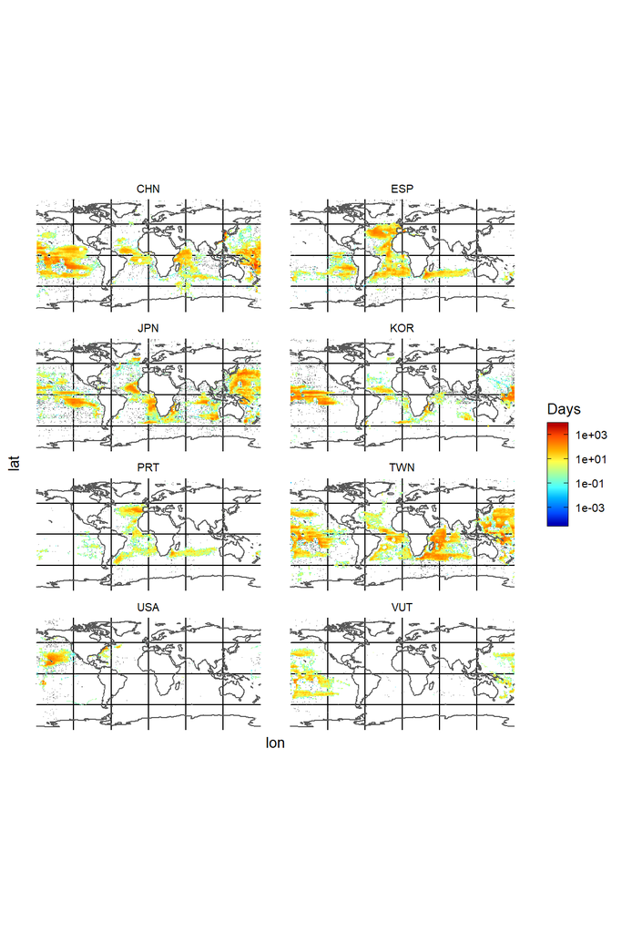

Fishing footrpint for longliners of the 8 main fishiing countries.

```r
# Define countries I need
# using their ISO3 codes
countries <- c("CHN", "ESP", "JPN", "KOR", "PRT", "TWN", "USA", "VUT")

global_fishing <- monthly_fishing %>%
  filter(best_flag %in% countries) %>% #Filter by country
  drop_na(best_flag) %>% #Filter unflagged vessels
  group_by(best_flag, lon, lat) %>% #Group by flag and pixel
  summarize(days = sum(hours, na.rm = T) / 24) %>% #calculate days
  ungroup()

# Get the world's coastline
coast <- ne_coastline(returnclass = "sf")

# Visualize with ggplot
ggplot(data = global_fishing) +
  geom_raster(aes(x = lon, y = lat, fill = days)) +
  geom_sf(data = coast) +
  facet_wrap(~best_flag, ncol = 2) +
  scale_fill_gradientn(colours = colorRamps::matlab.like(20), trans = "log10") +
  ggtheme_plot() +
  guides(fill = guide_colorbar(title = "Days",
                               frame.colour = "black",
                               ticks.colour = "black"))
```

You can think of the above maps as pictures of different individuals. Each country is an individual, and the areas where they fish are different characteristics of their face. It is also the equivalent of mapping points taken by NBA players from different positions in a court.

```r
nmf_data <- global_fishing %>%
  filter(days > 0) %>% # Just in case
  mutate(lonlat = paste(lon, lat, sep = "_")) %>% # Create a pair identifier
  select(best_flag, lonlat, days) %>%
  spread(lonlat, days, fill = 0) %>% #Flatten my table into a row
  select(-best_flag) %>% # Remove the flag identifier
  as.matrix() #matrix
```

## Analysis

With my $p$ matrix ready, I can now run $NMF$ and to calculate $h$ and $W$, which describe my data. The `NMF` package in R can automatically implement paralellization of NMF. In this case, this is useful because I will try 30 random starts for 6 different possible values of `r` (the number of features with which I want to describe my data). The following lines of code set it up, run it, and save it.

```r
# Define possible data sizes
r <- c(3, 5, 8, 10, 15, 20)

# Implement NMF with 30 random starts for each possible value of r
res <- nmf(nmf_data, r, nrun = 30)

# Save the results as an RDS file
saveRDS(res, file = here("final_project", "res.rds"))
```

Running NMF 30 times across 6 parameters is computationally intensive. I ran an initial, smaller test on a VM on Google ComputeEngine. The machine had 64 processors and 200 GB RAM. It took about 13 hours. An alternative is to run this code in the POD cluster, which is currently at 100% usage. The `SLURM` job submission file would be something like this:

```
#!bin/bash -l
#SBATCH --nodes=1 --ntasks-per-node=20
#SBATCH --mail-user=juancarlos@ucsb.edu
#SBATCH --mail-type=start,end
cd $SLURM_SUBMIT_DIR
module load R
Rscript final_project/scripts/run_nmf.R
```

The corresponding script (`run_nmf.R`) has the same code as the lines above, plus the library loading. It can be found on [GitHub](https://github.com/jcvdav/Spring2019/blob/master/final_project/scripts/run_nmf.R). POD usage has been maxed out over the last week. I have not been able to re-run this code for the purpose of this report. Instead, I will read in the results from a test run with $r = 10$.

```r
# Read in old run
res <- readRDS(file = here("final_project", "res.rds"))
```

# Results

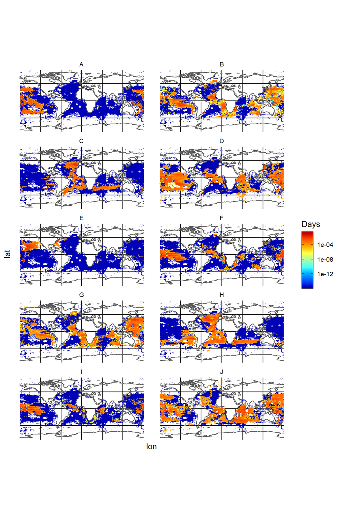

Features (10) describing the footrpint of different countries.

```r
# Extract basis
W <- basis(res)

# Extract coefficients
h <- coef(res)

# Add a column with letters to name each feature
features <- cbind(c(LETTERS[1:10]), h)

# Set columnames
colnames(features) <- c("feature", colnames(h))

# Create a tibble and use the lonlat variable
# to reconstruct the latitude and longitudes
features <- features %>%
  as_tibble() %>%
  gather(lonlat, days, -feature) %>%
  mutate(lon = str_extract(lonlat, ".+_"),
         lat = str_extract(lonlat, "_.+"),
         lon = str_remove(lon, "_"),
         lat = str_remove(lat, "_"),
         lon = as.numeric(lon),
         lat = as.numeric(lat),
         days = as.numeric(days))

# Visualie the 10 different features
(global_features <- ggplot(data = features) +
    geom_raster(aes(x = lon, y = lat, fill = days)) +
    geom_sf(data = coast) +
    facet_wrap(~feature, ncol = 2) +
    scale_fill_gradientn(colours = colorRamps::matlab.like(20), trans = "log10") +
    guides(fill = guide_colorbar(title = "Days",
                                 frame.colour = "black",
                                 ticks.colour = "black")) +
    ggtheme_plot())
```

```r
# Save plot
ggsave(plot = global_features,
       filename = here("final_project", "global_features.png"),
       width = 7.5,
       height = 10)
```

The spatial extent of the reconstruction (Fig. 3) matches the spatial extent of the original countries (Fig. 1). However, the magnitude of individual pixels seems to have much more error. This is likely due to the fact that fishing effort is log-normally distributed across pixels, as shown in the Figure 4.

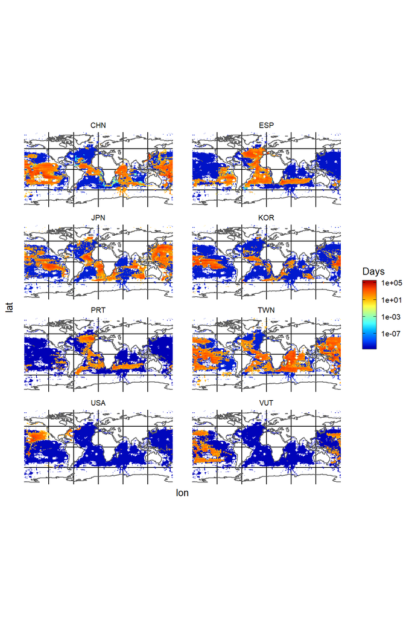

Reconstructed footrping of fishing activity for the top 8 fishing countries in the world.

```r
# Reconstruct footrpint by country
X_bar <- W %*% h
# Assign
X_bar <- cbind(countries, X_bar)

# Set column names
colnames(X_bar) <- c("country", colnames(h))

# Convert to a tibble and use latlon
# to recreate latitude and longitudes
X_pred <- X_bar %>%
  as_tibble() %>%
  gather(lonlat, hours, -country) %>%
  mutate(lon = str_extract(lonlat, ".+_"),
         lat = str_extract(lonlat, "_.+"),
         lon = str_remove(lon, "_"),
         lat = str_remove(lat, "_"),
         lon = as.numeric(lon),
         lat = as.numeric(lat),
         hours = as.numeric(hours))

# Plot it
(global_reconstructued <- ggplot(data = X_pred) +
    geom_raster(aes(x = lon, y = lat, fill = hours)) +
    geom_sf(data = coast) +
    facet_wrap(~country, ncol = 2) +
    scale_fill_gradientn(colours = colorRamps::matlab.like(20), trans = "log10") +
    guides(fill = guide_colorbar(title = "Days",
                                 frame.colour = "black",
                                 ticks.colour = "black")) +
    ggtheme_plot())
```

```r
# Save the plot
ggsave(plot = global_reconstructued,
       filename = here("final_project", "global_reconstructued.png"),
       width = 7.5,
       height = 10)
```

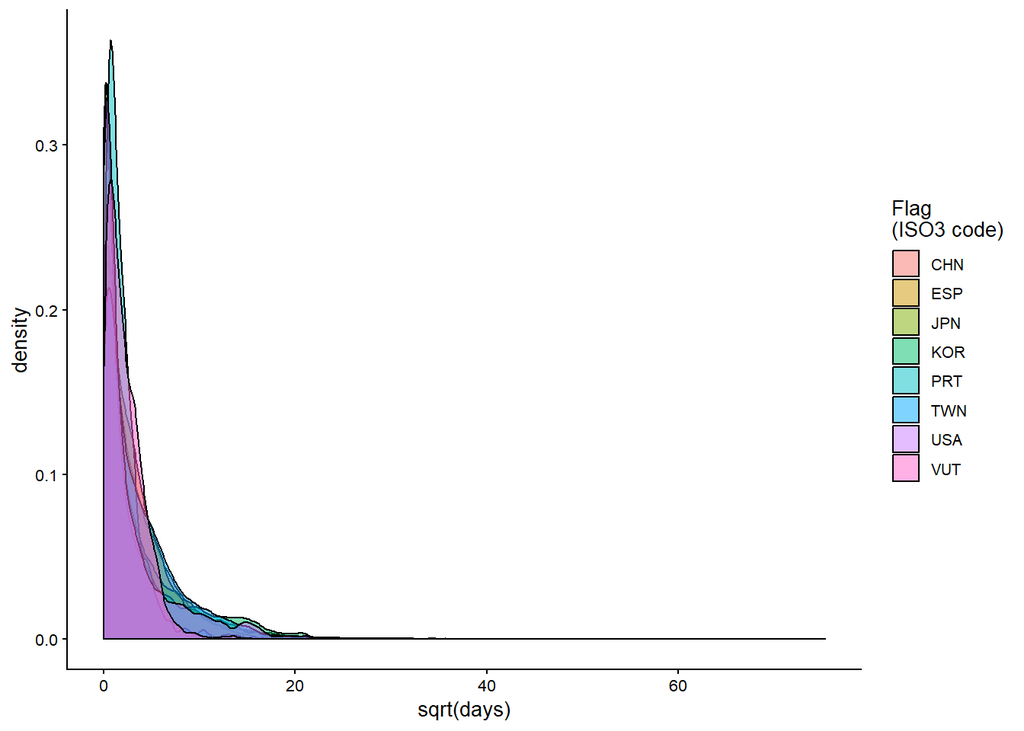

```r
ggplot(data = global_fishing, aes(x = sqrt(days), fill = best_flag)) +
  geom_density(alpha = 0.5) +
  ggtheme_plot() +
  guides(fill = guide_legend(title = "Flag\n(ISO3 code)"))
```

# Future steps

We have successfully described the spatial footprint of fisheries of each country. Evidently, many more factors derive the distribution of fishing effort, such as the distribution of fish and productivity of the waters. In following efforts, I will use enviornmental covariates and a regression approach to attempt to describe the relative influence and processes behind the distribution of fishing effort.